# Small-sample adjustments for F-tests using robust variance estimation in meta-regression

March 6, 2015

## Meta-analysis with dependent effect sizes

- **Meta-analysis** is a set of tools for synthesizing results from many different sources
- Studies often report **multiple** effect sizes
- Two methods for handling dependent effects:
  - **Univariate meta-analysis**, where each study contributes a single effect size, or
  - **Multivariate meta-analysis**, where the covariance structure of the multiple effect sizes is known.
- Neither approach is ideal

## Robust variance estimation

Robust variance estimation (RVE; Hedges, Tipton, & Johnson, 2010) produces asymptotically valid standard errors and hypothesis tests, **even if the error structure is mis-specified**.

- Accurate estimates of correlations between effect sizes are not needed.
- Meta-regressions estimated by weighted least squares (just like model-based multivariate meta-regression).
  - Weights can be based on effect size variances and rough imputations of correlations.
  - But exact inverse-variance weights are not needed.
- Variances of meta-regression coefficients estimated using a "sandwich" formula (Liang & Zeger, 1986).

## Hypothesis testing

In large samples, we can use RVE to construct hypothesis tests.

- For testing a single meta-regression coefficient, the z statistic \(\left(\frac{\text{estimate}}{\text{robust SE}}\right)\) follows a standard normal distribution if \(m\) is "big enough."
- Tipton (in press) devised small-sample corrections for t-tests. These corrections involve two parts:
  - Adjustments to the robust variance estimator
  - Estimated degrees of freedom for the t-distribution (using a Satterthwaite approximation)
  - These degrees of freedom differ **for each covariate in the model**.

## Tests of multiple meta-regression coefficients

- Meta-analysts will often need to test hypotheses involving more than one meta-regression coefficient.
  - Test equality of several levels of a moderator
  - Test of overall model fit
- For simulatenously testing several meta-regression coefficients, one can use a Wald statistic \[Q = \left(\text{estimates}\right)' \left(\text{RVE matrix}'\right)^{-1} \left(\text{estimates}\right)\]
- In large samples, we would expect \(Q\) to follow a chi-squared distribution with \(q\) degrees of freedom.
- Simulation results suggest that this test can have **severely inflated** Type I error.

## Small sample F-tests

We follow a two-part strategy for constructing small-sample tests:

- Adjustments to the robust variance estimator
  - based on McCaffrey, Bell, & Botts' (2001) "bias-reduced linearization" approach.
- Estimated degrees of freedom for the F-distribution
  - but how to estimate these degrees of freedom?
- Drawing on extant literature, we investigated a wide variety of possible corrections.
  - Fai-Cornelius (1996): mixed models
  - Cai-Hayes (2008): heteroskedasticity robust standard errors
  - Zhang (2012, 2013): heteroskedastic ANOVA/MANOVA
  - Pan-Wall (2002): generalized estimating equations

## The Winner: \(T^2_Z\)

- The paper provides results for five different corrections. Here, however, we'll focus on only the one that works best.
- The \(T^2_Z\) approach \[c \times Q/q \sim F(q, df)\] where \(df\) is estimated by matching the mean and **total variance** of the RVE matrix.
- The \(T^2_Z\) is best in two regards
  - It is (almost) always level-alpha
  - It is more powerful than any of the other level-alpha estimators (i.e., always has error rates closer to nominal)

## Simulated type-I error rate of \(\chi^2\) test

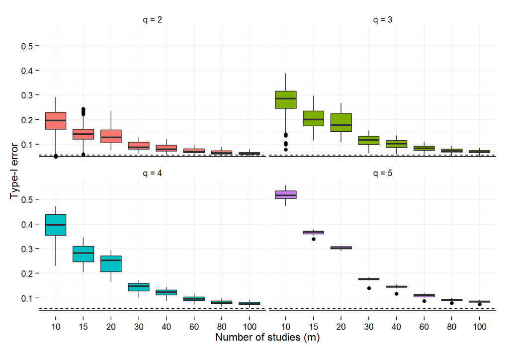

## Simulation results: \(T^2_Z\)

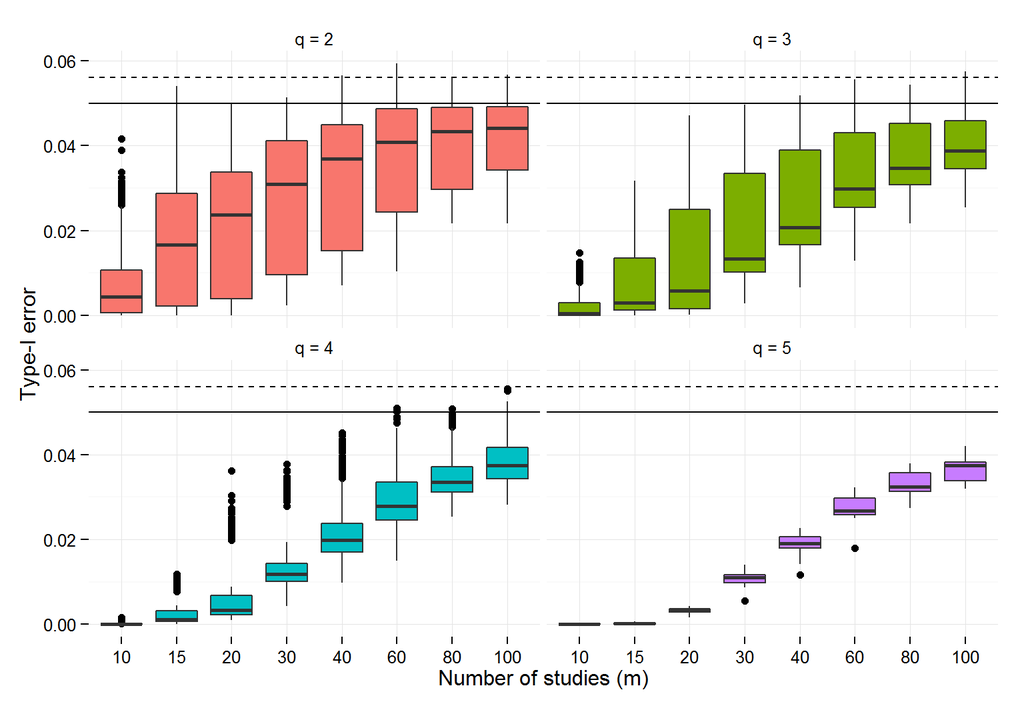

## Example: Wilson et al. (2011)

- Wilson, Lipsey, Tanner-Smith, Huang, & Steinka-Fry (2011) synthesis of effects of dropout prevention/intervention programs.
  - Primary outcomes: school completion, school dropout
  - \(m = 152\) studies, containing 385 effect size estimates
- Meta-regression model including several categorical moderators

| Moderator | q | Chi-sq | p-value | T-squared Z | d.f. | p-value |
| --- | --- | --- | --- | --- | --- | --- |
| Study design | 2 | 0.23 | 0.796 | 0.22 | 43 | 0.800 |
| Outcome measure | 3 | 0.91 | 0.436 | 0.84 | 22 | 0.488 |
| Evaluator independence | 3 | 3.11 | 0.029 | 2.78 | 17 | 0.073 |
| Implementation quality | 2 | 14.15 | <0.001 | 13.78 | 37 | <0.001 |
| Program format | 3 | 3.85 | 0.011 | 3.65 | 38 | 0.021 |

## Conclusions and future work

- Like Tipton (in press) found with the small-sample t-test…
  - The performance of the large-sample test depends on **features of the covariates**, not just sample size.
  - Consequently, it is hard to know a priori what constitutes a "big enough" sample.
- We therefore recommend that small-sample corrections **should always be used** in practice.
- We provide prototype software in R (upon request), and are working on implementing it fully into the **robumeta** R package and Stata macro and the **metafor** R package (Viechtbauer, 2010).

## Small-sample adjustments for F-tests using robust variance estimation in meta-regression

James E. Pustejovsky - pusto@austin.utexas.edu

Elizabeth Tipton - tipton@tc.columbia.edu

## Simulation results

## Simulation results: EDT test

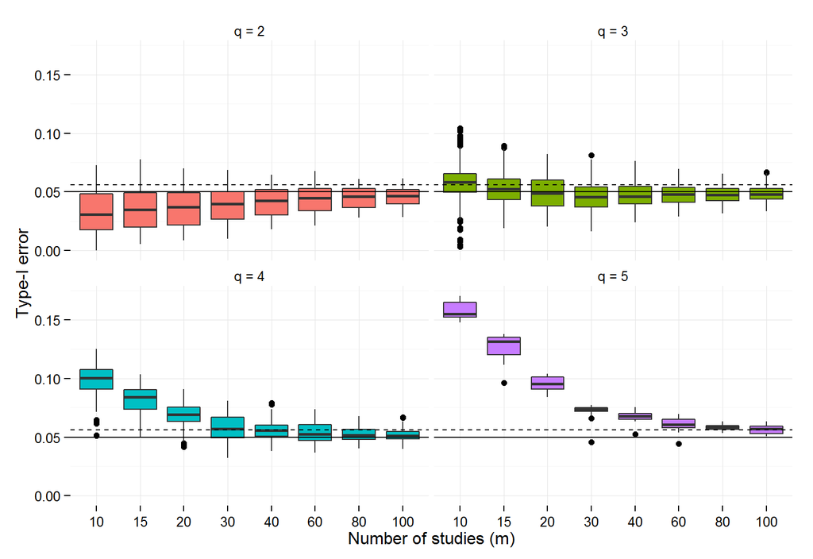

## Comparison of small-sample corrections

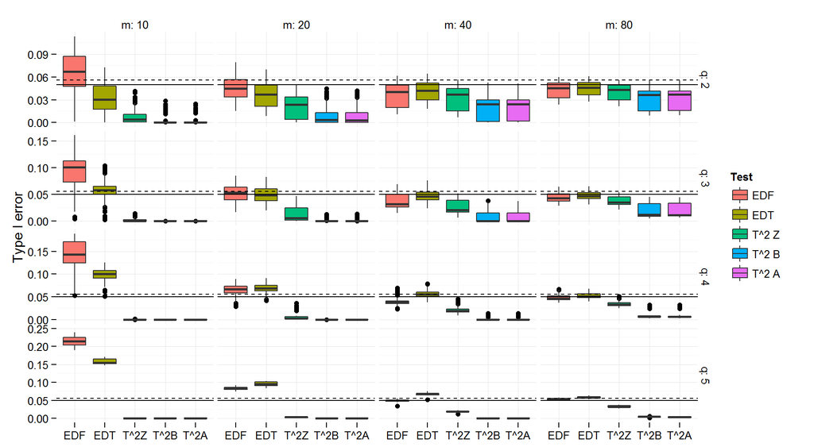